# oneSampleLogRankTest

Divy Kangeyan

Kite Pharma, A Gilead Company  
dkangeyan@kitepharma.com

Jin Xie

Kite Pharma, A Gilead Company  
jin.xie3@gilead.com

Qinghua Song

Kite Pharma, A Gilead Company  
qsong@kitepharma.com

December 21, 2023

```r
library(OneSampleLogRankTest)
```

## One sample log rank test

Log-rank test is a popular hypothesis test used to compared survival distribution between two groups. When there are no control or comparator group or obtaining such group is difficult, it is suitable to compare survival outcomes to a demographically- matched reference population. In this package we present existing methods to conduct such test named one sample log rank test.

## One sample log rank test for large sample sizes

Approximate one sample log rank test based on Chi-squared distribution can be applied to larger sample sizes (above 20 samples). *oneSampleLogRankTest* function would output Standardized Mortality Ratio (SMR), p-value and confidence interval around SMR. Statistical test is conducted based on Finkelstein et al. (2003) paper.

```r
data(dataSurv, package = "OneSampleLogRankTest")
data(dataPop_2018_2021_race_sex_eth, package = "OneSampleLogRankTest")

## approximate one sample log rank test
oneSampleLogRankTest(dataSurv, dataPop_2018_2021_race_sex_eth,
                     type = "approximate")
```

```
#> $p.value
#> [1] 0.1216871
#>
#> $estimate
#>   std_mort_ratio_est       lwr      upr
#> 1           1.531173 0.8302562 2.823816
```

Mortality rate in the sample of interest is 1.531 times that in the general population and it is not significantly different from the general population.

## Kaplan-Meier Curve Visualization

Kaplan-Meier curve is a useful visualization tool to compared the survival outcome in the population of interest and the general population. Type of test would be one of the argument in this function and the p-value would be displayed accordingly.

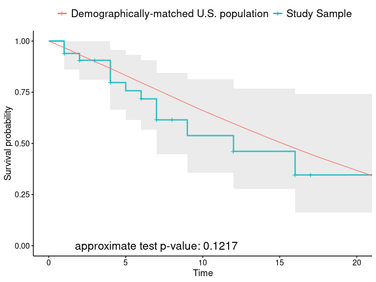

```r
plotKM(dataSurv, dataPop_2018_2021_race_sex_eth, type = "approximate")
```

## Small-Sample Test

For a small sample set and exact test would be applied as described in F D Liddel (1984) paper.

```r
data(dataSurv_small, package = "OneSampleLogRankTest")

## exact test version of one sample log rank test for small sample size
oneSampleLogRankTest(dataSurv_small, dataPop_2018_2021_race_sex_eth)
```

```
#> $p.value
#> [1] 0.00729568
#>
#> $estimate
#>   std_mort_ratio_est      lwr      upr
#> 1           3.283826 1.417723 6.470446
```

In the small data set, mortality ratio is significantly higher compared to the general population and it is about 3.3 fold higher.

### Kaplan-Meier Curve Visualization

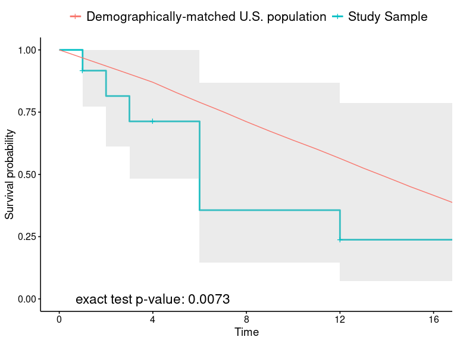

```r
plotKM(dataSurv_small, dataPop_2018_2021_race_sex_eth, type = "exact")
```

## Application of one sample log rank test in simulated clinical data

A simulated data set with 500 patients were generated based on sex, race, age, and survival time distribution based on real clinical trial data. Female to male ratio was 30:70 and there were four different race groups: Asian, Black, Other / More than one race and White.

This simulated clinical trial data will be compared against CDC Wonder database data to assess if the survival outcomes are comparable or significantly different between this population and general population.

### SMR and hypothesis testing

```r
data(simulated_clinical_data)

oneSampleLogRankTest(simulated_clinical_data, dataPop_2018_2021_race_sex_eth,
                     type = "approximate")
```

```
#> $p.value
#> [1] 0
#>
#> $estimate
#>   std_mort_ratio_est      lwr      upr
#> 1           9.420534 8.014948 11.07262
```

In the simulated clinical trial, the mortality ratio is around 9.42 times that of general population and it is highly significant.

### Visualization with K-M Curve

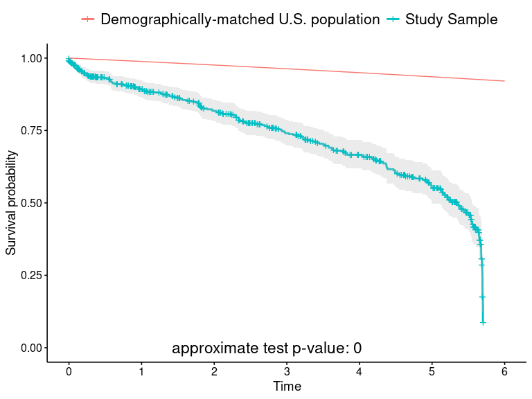

```r
plotKM(simulated_clinical_data, dataPop_2018_2021_race_sex_eth, type = "approximate")
```

Kaplan-Meir curve clearly shows that the simulated patient population is different from the general population.